# GR5241 HW2

JIE LI

February 12, 2019

## Problem 1 PCA

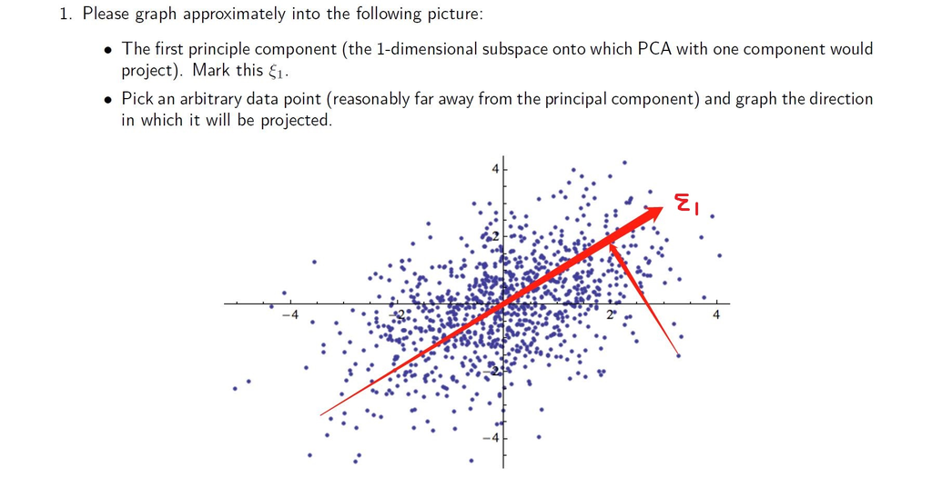

### 2

#### a)

There are 10304 principle components in total

#### b)

$$\hat{X} = UDV^T$$
$U$ is a 100x10304 left sigular vector.

$D$ is a 10304x10304 diagonal matrix contains eigenvalues for each principle component such that $d_1 \geq d_2 \geq ... \geq d_{10304}$

$V^T$ is a 10304x10304 right sigular orthogonal matrix, each row stands for each principle component spaces, and column stands for feature spaces.

Therefore, the first 48 principle componets to represent:

$$\hat{X_i} = \bar{x_i} + x_{i,1}v_{i,1} + x_{i,2}v_{i,2} +...+ x_{i,48}v_{i,48}$$

## Problem 2

### 1

```r
library(quantmod)
library(factoextra)
library(ggplot2)

company = c("MMM","AXP","AAPL","BA","CAT", "CVX", "CSCO","KO","DWDP","XOM","GS","HD","IBM","INTC","JNJ","JPM","MCD","MRK","MSFT","NKE","PFE","PG","TRV","UNH","UTX","VZ","V","WMT","WBA","DIS")

data = c()
for(i in company)
{
  data = cbind(data, getSymbols(i, auto.assign = F, from = "2018-01-01", to = "2019-01-01")[,4])
}
colnames(data) = gsub(".Close", "", colnames(data))
```

### 2

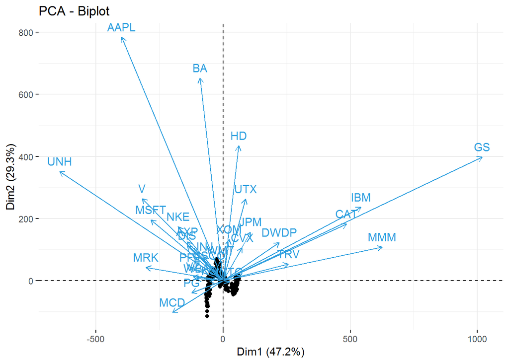

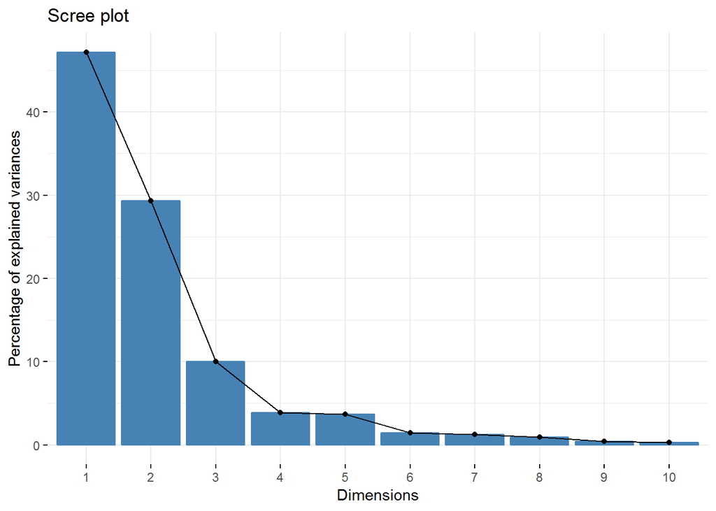

```
##
## [[3]]
## Importance of components:
##                            Comp.1     Comp.2     Comp.3      Comp.4
## Standard deviation     38.9464635 30.7083169 17.9142695 11.18089027
## Proportion of Variance  0.4720066  0.2934432  0.0998643  0.03890136
## Cumulative Proportion   0.4720066  0.7654498  0.8653141  0.90421549
##                             Comp.5     Comp.6     Comp.7     Comp.8
## Standard deviation     10.89296635 6.85795468 6.41178665 5.54224433
## Proportion of Variance  0.03692363 0.01463529 0.01279293 0.00955836
## Cumulative Proportion   0.94113912 0.95577441 0.96856734 0.97812570
##                             Comp.9     Comp.10     Comp.11     Comp.12
## Standard deviation     3.715171986 3.158836458 3.028046131 2.609657054
## Proportion of Variance 0.004295066 0.003105034 0.002853232 0.002119234
## Cumulative Proportion  0.982420767 0.985525801 0.988379032 0.990498266
##                            Comp.13     Comp.14     Comp.15     Comp.16
## Standard deviation     2.271094013 2.171198293 1.942200991 1.817296039
## Proportion of Variance 0.001605027 0.001466935 0.001173817 0.001027693
## Cumulative Proportion  0.992103293 0.993570229 0.994744046 0.995771739
##                             Comp.17      Comp.18      Comp.19      Comp.20
## Standard deviation     1.6735621994 1.4889989187 1.2942827797 1.1944458737
## Proportion of Variance 0.0008715569 0.0006899233 0.0005212792 0.0004439612
## Cumulative Proportion  0.9966432955 0.9973332188 0.9978544980 0.9982984591
##                             Comp.21      Comp.22     Comp.23      Comp.24
## Standard deviation     1.0519123494 0.9707014056 0.922032483 0.8474031657
## Proportion of Variance 0.0003443271 0.0002932131 0.000264548 0.0002234561
## Cumulative Proportion  0.9986427862 0.9989359993 0.999200547 0.9994240034
##                             Comp.25      Comp.26      Comp.27      Comp.28
## Standard deviation     0.7620331386 0.6860093069 5.298655e-01 5.189041e-01
## Proportion of Variance 0.0001807007 0.0001464442 8.736619e-05 8.378885e-05
## Cumulative Proportion  0.9996047040 0.9997511482 9.998385e-01 9.999223e-01
##                             Comp.29      Comp.30
## Standard deviation     3.802759e-01 3.241517e-01
## Proportion of Variance 4.499971e-05 3.269705e-05
## Cumulative Proportion  9.999673e-01 1.000000e+00
```

```r
pc.pipline = function(data, scale, summary)
{
  pc = princomp(data, cor= scale)
  a = fviz_pca_biplot(pc, geom = "point", repel = F, col.var = "#2E9FDF")
  b = fviz_eig(pc)
  if(summary == T)
    c = summary(pc)
  else
    c = NULL
  return(list(a, b, c))
}

pc.pipline(data, F, T)
```

There are some structures in the biplot

- left direction is most likely related to food, healthcare and pharamcy
- up direction is about chemical, energy and retail industry
- right direction is related to information technologies

Based on summary table, when choose 6 principle components, the cumulative Proportion is reaching 95%

### 3

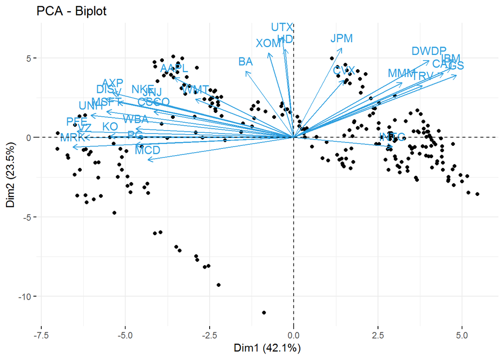

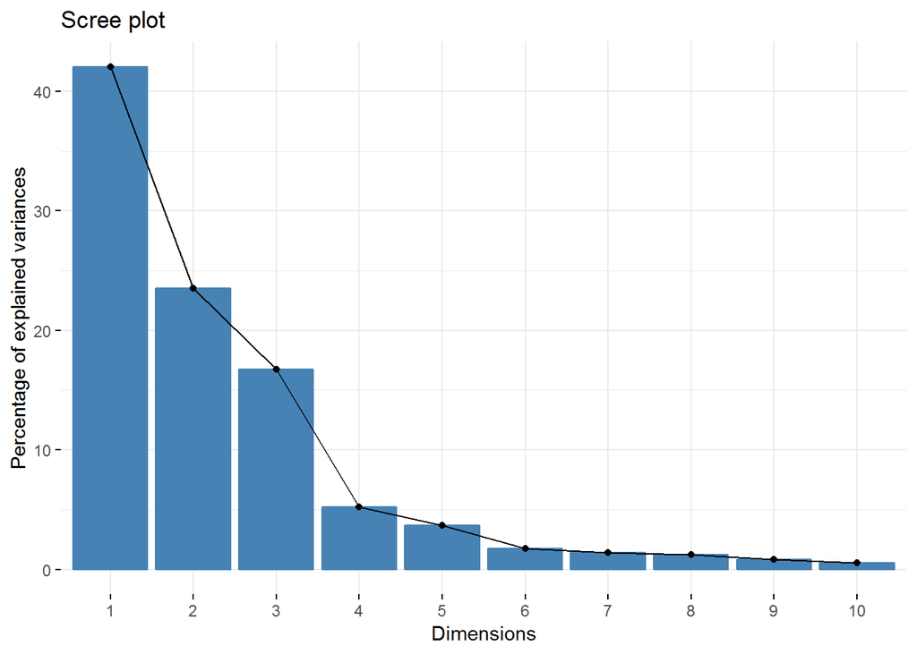

```
##
## [[3]]
## Importance of components:
##                           Comp.1    Comp.2    Comp.3     Comp.4     Comp.5
## Standard deviation     3.5523912 2.6555330 2.2395918 1.25389698 1.04804610
## Proportion of Variance 0.4206495 0.2350618 0.1671924 0.05240859 0.03661335
## Cumulative Proportion  0.4206495 0.6557113 0.8229037 0.87531227 0.91192562
##                            Comp.6     Comp.7     Comp.8      Comp.9
## Standard deviation     0.72565783 0.64167393 0.60387369 0.505965714
## Proportion of Variance 0.01755264 0.01372485 0.01215545 0.008533377
## Cumulative Proportion  0.92947827 0.94320311 0.95535856 0.963891939
##                            Comp.10     Comp.11    Comp.12     Comp.13
## Standard deviation     0.410284132 0.396849631 0.36373231 0.328427242
## Proportion of Variance 0.005611102 0.005249654 0.00441004 0.003595482
## Cumulative Proportion  0.969503041 0.974752696 0.97916274 0.982758217
##                            Comp.14     Comp.15     Comp.16     Comp.17
## Standard deviation     0.272696214 0.260903634 0.230339465 0.224142234
## Proportion of Variance 0.002478774 0.002269024 0.001768542 0.001674658
## Cumulative Proportion  0.985236991 0.987506015 0.989274557 0.990949215
##                           Comp.18    Comp.19     Comp.20      Comp.21
## Standard deviation     0.21427928 0.20014298 0.191223574 0.1670968650
## Proportion of Variance 0.00153052 0.00133524 0.001218882 0.0009307121
## Cumulative Proportion  0.99247974 0.99381498 0.995033858 0.9959645697
##                             Comp.22      Comp.23      Comp.24      Comp.25
## Standard deviation     0.1514865235 0.1452216399 0.1344319571 0.1244578452
## Proportion of Variance 0.0007649389 0.0007029775 0.0006023984 0.0005163252
## Cumulative Proportion  0.9967295086 0.9974324861 0.9980348844 0.9985512096
##                             Comp.26      Comp.27      Comp.28      Comp.29
## Standard deviation     0.1081772731 0.1059578703 0.0973126302 0.0763609557
## Proportion of Variance 0.0003900774 0.0003742357 0.0003156583 0.0001943665
## Cumulative Proportion  0.9989412870 0.9993155227 0.9996311810 0.9998255475
##                             Comp.30
## Standard deviation     0.0723434564
## Proportion of Variance 0.0001744525
## Cumulative Proportion  1.0000000000
```

```r
pc.pipline(data, T, T)
```

Based on summary table, when choose 8 principle components, the cumulative Proportion is reaching 95%

### 4

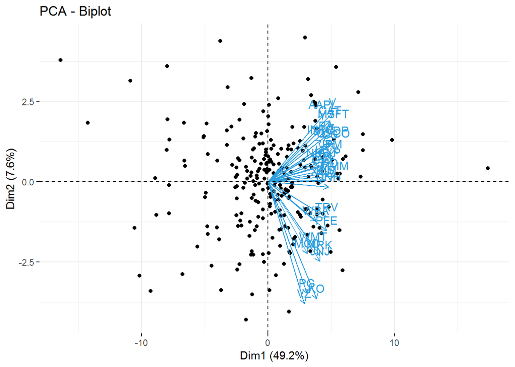

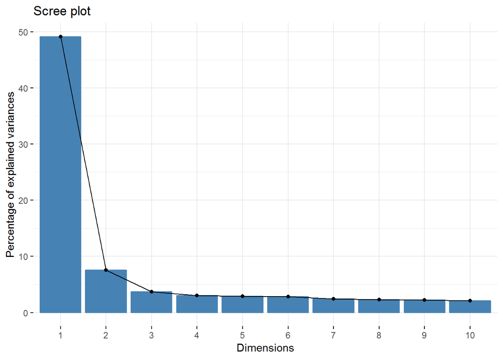

```
##
## [[3]]
## Importance of components:
##                           Comp.1     Comp.2     Comp.3     Comp.4
## Standard deviation     3.8404888 1.50885324 1.05290551 0.95275091
## Proportion of Variance 0.4916451 0.07588794 0.03695367 0.03025781
## Cumulative Proportion  0.4916451 0.56753308 0.60448675 0.63474456
##                            Comp.5     Comp.6     Comp.7     Comp.8
## Standard deviation     0.93304126 0.91670678 0.85279863 0.83329930
## Proportion of Variance 0.02901887 0.02801171 0.02424218 0.02314626
## Cumulative Proportion  0.66376343 0.69177514 0.71601732 0.73916358
##                            Comp.9    Comp.10   Comp.11    Comp.12
## Standard deviation     0.81591802 0.79273677 0.7739225 0.76333486
## Proportion of Variance 0.02219074 0.02094772 0.0199652 0.01942267
## Cumulative Proportion  0.76135432 0.78230204 0.8022672 0.82168991
##                           Comp.13    Comp.14    Comp.15    Comp.16
## Standard deviation     0.74118206 0.68191948 0.66388756 0.63920272
## Proportion of Variance 0.01831169 0.01550047 0.01469156 0.01361934
## Cumulative Proportion  0.84000160 0.85550208 0.87019363 0.88381297
##                           Comp.17    Comp.18    Comp.19    Comp.20
## Standard deviation     0.62841102 0.61011078 0.58701922 0.55889731
## Proportion of Variance 0.01316335 0.01240784 0.01148639 0.01041221
## Cumulative Proportion  0.89697632 0.90938416 0.92087054 0.93128275
##                            Comp.21     Comp.22     Comp.23     Comp.24
## Standard deviation     0.545656307 0.517781493 0.500702736 0.489181836
## Proportion of Variance 0.009924694 0.008936589 0.008356774 0.007976629
## Cumulative Proportion  0.941207441 0.950144030 0.958500804 0.966477433
##                           Comp.25     Comp.26     Comp.27     Comp.28
## Standard deviation     0.46764570 0.457587555 0.418239405 0.406139487
## Proportion of Variance 0.00728975 0.006979546 0.005830807 0.005498309
## Cumulative Proportion  0.97376718 0.980746729 0.986577536 0.992075845
##                           Comp.29     Comp.30
## Standard deviation     0.36465450 0.323653743
## Proportion of Variance 0.00443243 0.003491725
## Cumulative Proportion  0.99650828 1.000000000
```

```r
data = as.matrix(data)
data.today = as.matrix(data[1:250,])
data.tmr = as.matrix(data[2:251,])
return = (data.tmr - data.today)/data.today

pc.pipline(return, T, T)
```

If each stock were fluctuating up and down randomly and independent of all the stocks, then expect each principle component has similar weight because each direction catchs different information from data.

## Problem 3

Let T be the centered inner product matrix with elements $<Z_i - \bar{Z_i}, Z_i - \bar{Z}>$, then $\sum_{i,i'}^n{(s_{i,i'} - <z_i - \bar{z}, z_{i'} - \bar{z}>)}$

Assume that the eign decomposition of $S$ and $T$ are $UD^2U^T$ and $\tilde{U}\tilde{D}^2\tilde{U}^T$

$$S_c(z_1, z_2, ..., z_n) = tr[(UD^2U^T - \tilde{U}\tilde{D}^2\tilde{U}^T)^2] = tr[D^4U^2U^{2T} + \tilde{D}^4\tilde{U}^2\tilde{U}^{2T} - 2D^2U^T\tilde{U}\tilde{D}^2\tilde{U}^TU]$$

$$=tr[D^4 + \tilde{D}^4 - 2D^2U^T\tilde{U}\tilde{D}^2\tilde{U}^TU]$$

Let $A = U^T\tilde{U}$, where $a_{ij}$ is the $(i,j)th$ element of $A$

$$\frac{\partial S_c}{\partial \tilde{d}^2} = d^2 + \tilde{d}^2 - 2\sum_i^n d_i^2 a_{ij}^2$$

$$= 2\tilde{d}^2 - 2\sum_i^n d_i^2 a_{ij}^2$$

Minimizing $S_c(z_1, z_2, ..., z_n) \rightarrow \frac{\partial S_c}{\partial \tilde{d}^2} = 0$

$\rightarrow \tilde{d}^2 = \sum_i^n d_i^2 a_{ij}^2$

$\rightarrow max \sum_i^n d_i^2 a_{ij}^2 = \sum_i^n (\tilde{u}_i^TUD^2U^T\tilde{u}_i)^2$

$\rightarrow S_c(z_1, z_2, ..., z_n) = X^T\tilde{U}$, where $\tilde{U}$ is $k \times k$ orthogonal matrix, and $ith$ column stands for each principle component. Therefore, $X^T\tilde{U}$ is mapping to the first k principle components with the largest variance $d^2$